# INTRODUCTION TO GGPLOT2: GEOMETRIES

The shape attribute values could be from number 21-25 whose both fill and color can be controlled independently.

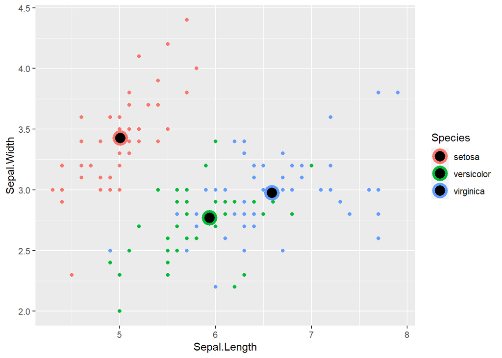

```r
ggplot(iris, aes(Sepal.Length, Sepal.Width,
                 col = Species)) +
  geom_point() +
  geom_point(data = iris.summary,
             shape = 21,
             size = 5,
             fill = "black",
             stroke = 2)
```

`geom_jitter()` is a shortcut to using position argument to change the position from `identity` to `jitter`.

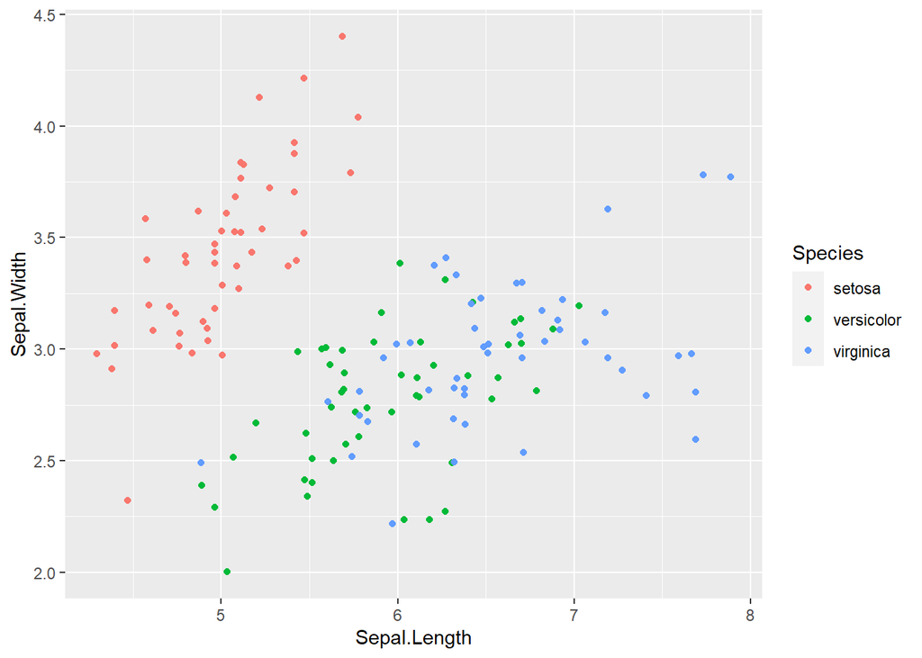

```r
ggplot(iris, aes(Sepal.Length, Sepal.Width,
       col = Species)) +
  geom_jitter()
```

To deal with overplotting of points, we adjust the alpha-blending, which works great as an attribute. This helps us to see regions of high density.

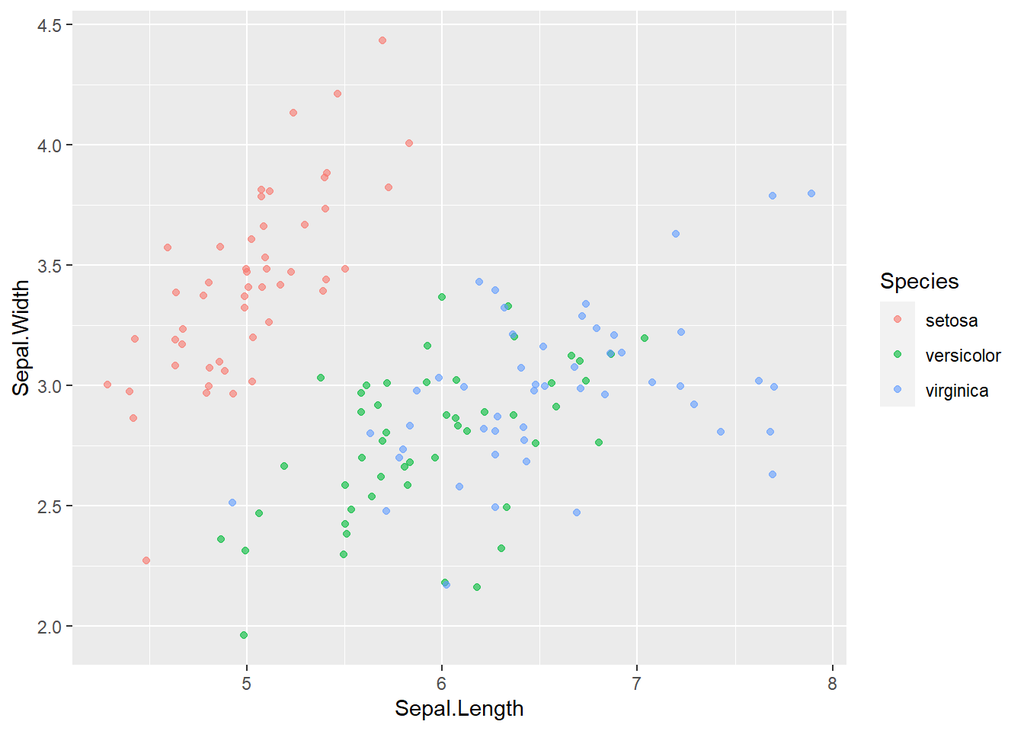

```r
ggplot(iris, aes(Sepal.Length, Sepal.Width,
                 col = Species)) +
  geom_jitter(alpha = 0.6)
```

Another way to deal with overplotting is to change the symbol to a hollow circle, which is shape 1.

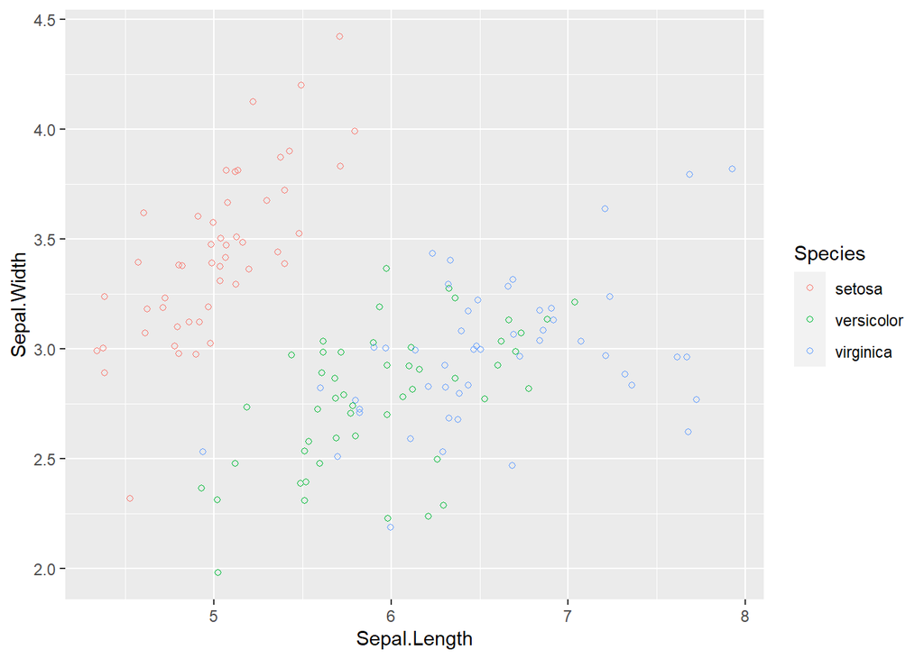

```r
ggplot(iris, aes(Sepal.Length, Sepal.Width,
                 col = Species)) +
  geom_jitter(shape = 1)
```

Both of these options help with visual communication because they aid in perception. We can more accurately and quickly see what the data is actually showing, even if jittering adds some random noise to both axes. It is always recommended to optimize shape, size and alpha blending of points in a scatter plot.

### 3.2 Overplotting

Scatter plots are intuitive, easily understood, and very common, but we must always consider overplotting, particularly in the following situations:

- large datasets: small points are suitable for large datasets with regions of high density (lots of overlapping).

Load the `diamonds` dataset from the **ggplot2** package:

```r
data("diamonds")
```

Plot `price` vs. `carat`, colored by `clarity`:

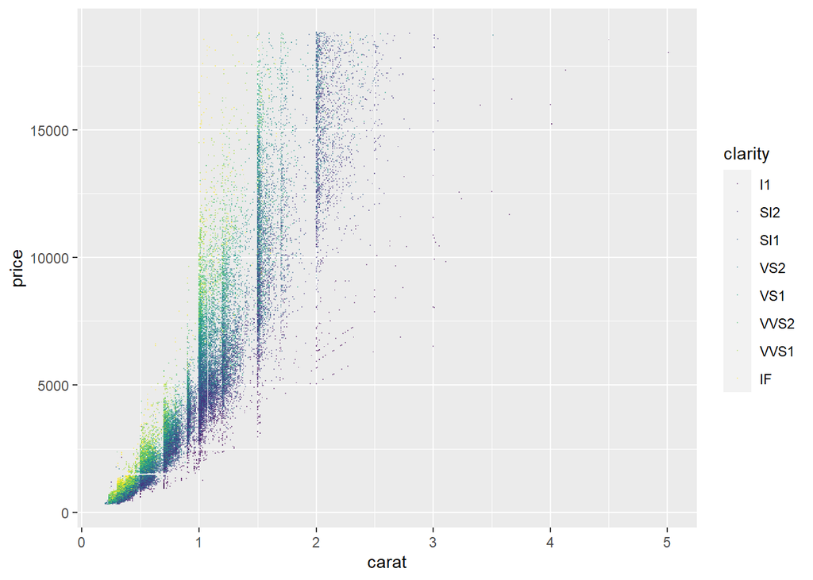

```r
ggplot(diamonds, aes(carat, price,
                     col = clarity)) +
  geom_point(shape = ".",
             alpha = 0.5)
```

- Aligned values on a single axis: this occurs when one axis is continuous and the other is categorical, which can be overcome with some form of jittering.

Load the `mtcars` dataset and transform `cyl` and am columns into categorical variables:

```r
data("mtcars")
mtcars <- mtcars %>%
  mutate(fcyl = as.factor(cyl),
         fam = as.factor(am))
```

Plot with default points:

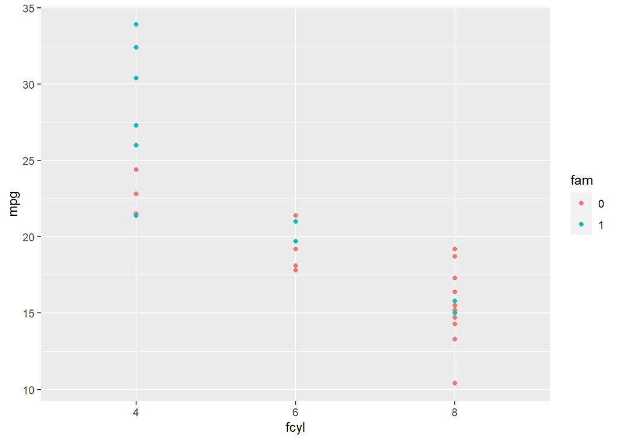

```r
ggplot(mtcars, aes(fcyl, mpg,
                   col = fam)) +
  geom_point()
```

Alter the point positions by jittering:

[figure not shown]

```r
ggplot(mtcars, aes(fcyl, mpg,
                   col = fam)) +
geom_point(position = position_jitter(width = 0.3))
```

Alternatively jitter and dodge the point positions:

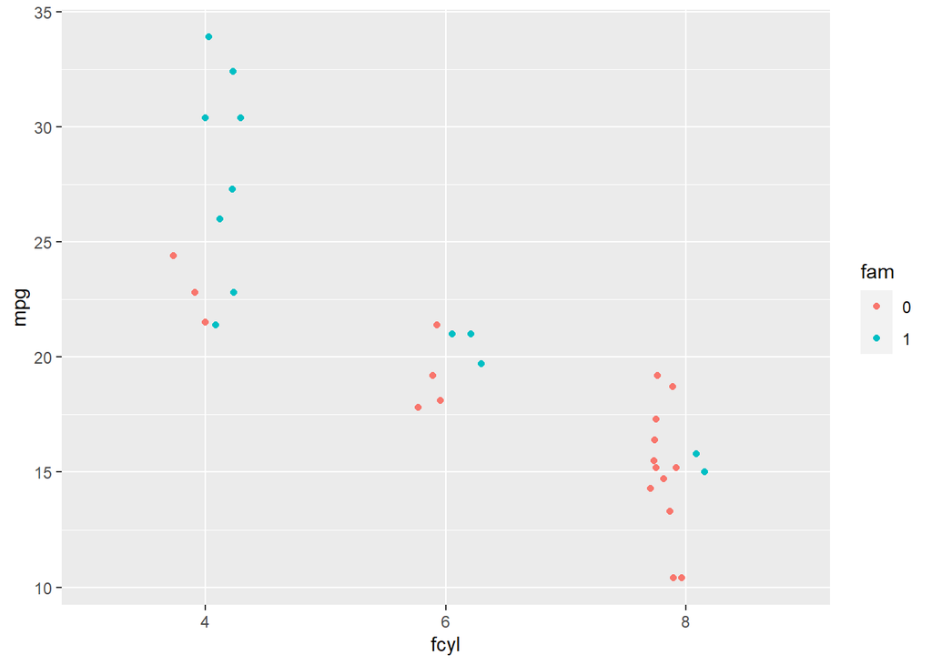

```r
ggplot(mtcars, aes(fcyl, mpg,
                   col = fam)) +
  geom_point(position = position_jitterdodge(jitter.width = 0.3,
                                             dodge.width = 0.3))
```

- Low-precision data: this results from low-resolution measurements like in the `iris` dataset, which is measured to 1 mm precision. In this case we can jitter on both the x and y axis. **jitter** can be a geom itself, an argument in `geom_point()`, or a position function.

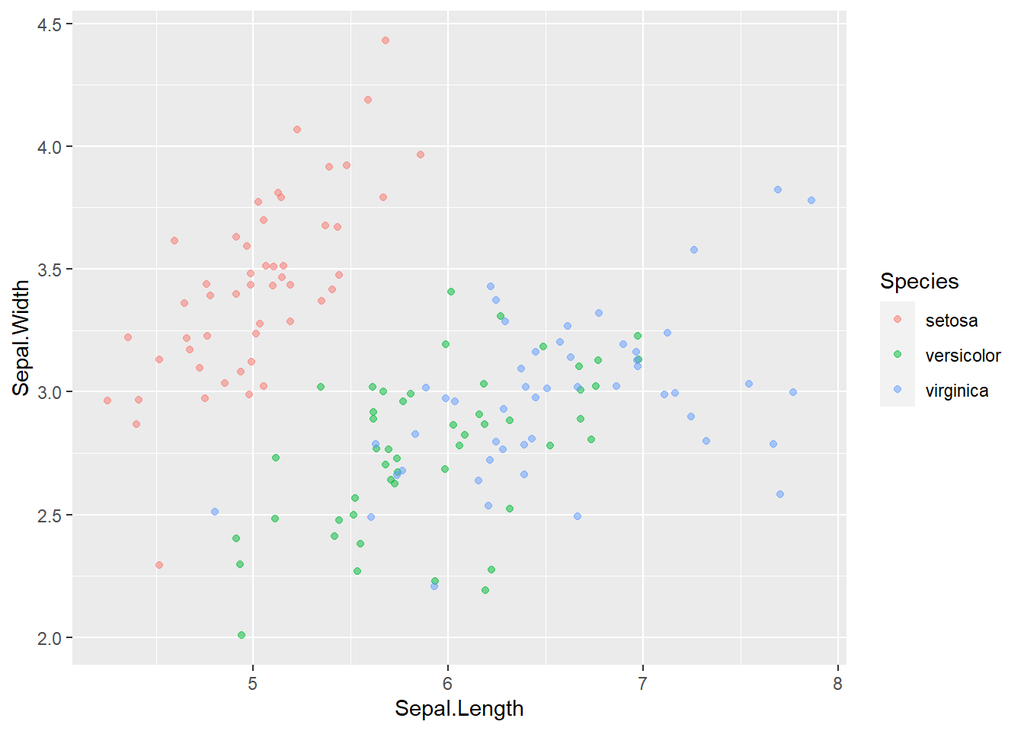

```r
ggplot(iris, aes(Sepal.Length, Sepal.Width,
                 col = Species)) +
  geom_jitter(alpha = 0.5,
              width = 0.1)
```

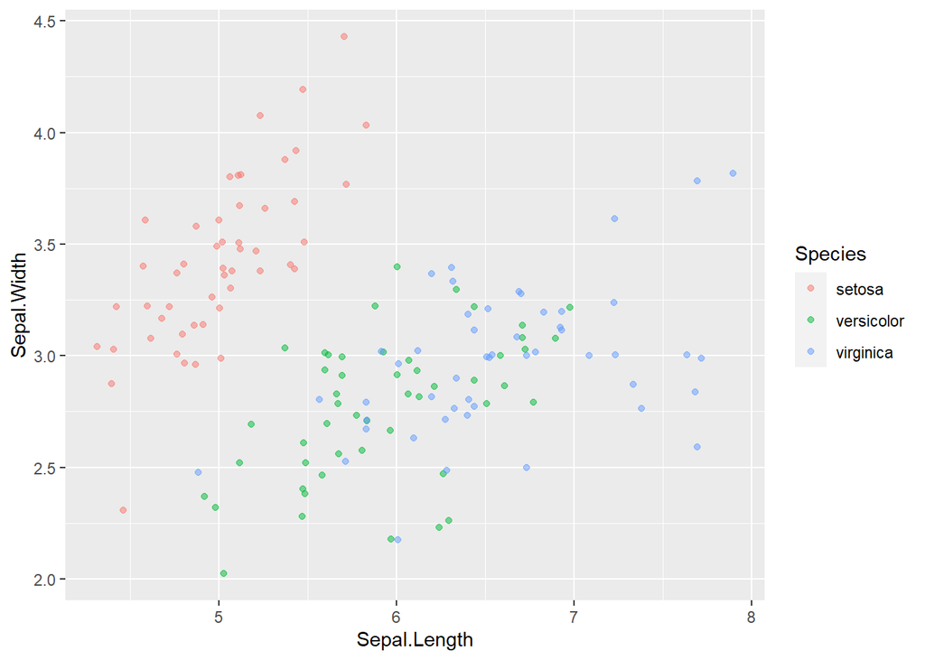

```r
ggplot(iris, aes(Sepal.Length, Sepal.Width,
                 col = Species)) +
  geom_point(alpha = 0.5,
              position = "jitter")
```

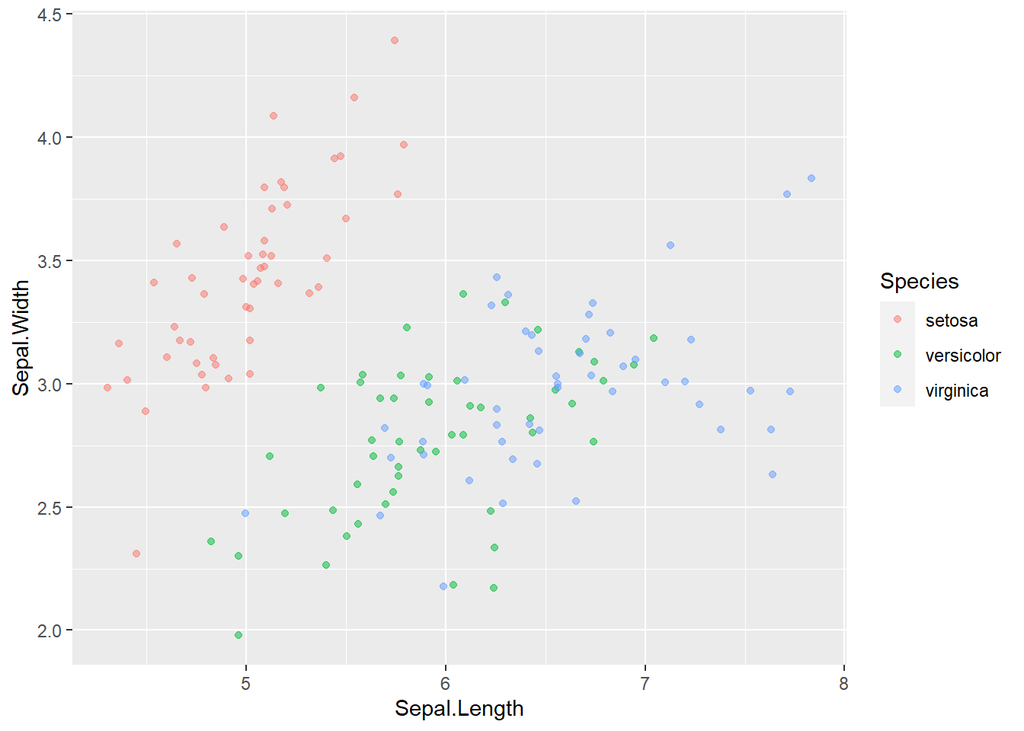

```r
ggplot(iris, aes(Sepal.Length, Sepal.Width,
                 col = Species)) +
  geom_point(alpha = 0.5,
             position = position_jitter(width = 0.1))
```

- Integer data: this can be type integer or factor variables. You will typically have a small, defined number of intersections between two variables, which is similar to low precision data.

Load and examine the `Vocab` dataset from the **carData** package, which contains the years of education and vocabulary test scores from respondents to US General Social Surveys from 1972-2004:

```r
library(carData)
data(Vocab)
str(Vocab)
```

```
## 'data.frame':    30351 obs. of  4 variables:
##  $ year      : num  1974 1974 1974 1974 1974 ...
##  $ sex       : Factor w/ 2 levels "Female","Male": 2 2 1 1 1 2 2 2 1 1 ...
##  $ education : num  14 16 10 10 12 16 17 10 12 11 ...
##  $ vocabulary: num  9 9 9 5 8 8 9 5 3 5 ...
##  - attr(*, "na.action")= 'omit' Named int [1:32115] 1 2 3 4 5 6 7 8 9 10 ...
##   ..- attr(*, "names")= chr [1:32115] "19720001" "19720002" "19720003" "19720004" ...
```

Draw a scatter plot of `vocabulary` vs. `education`:

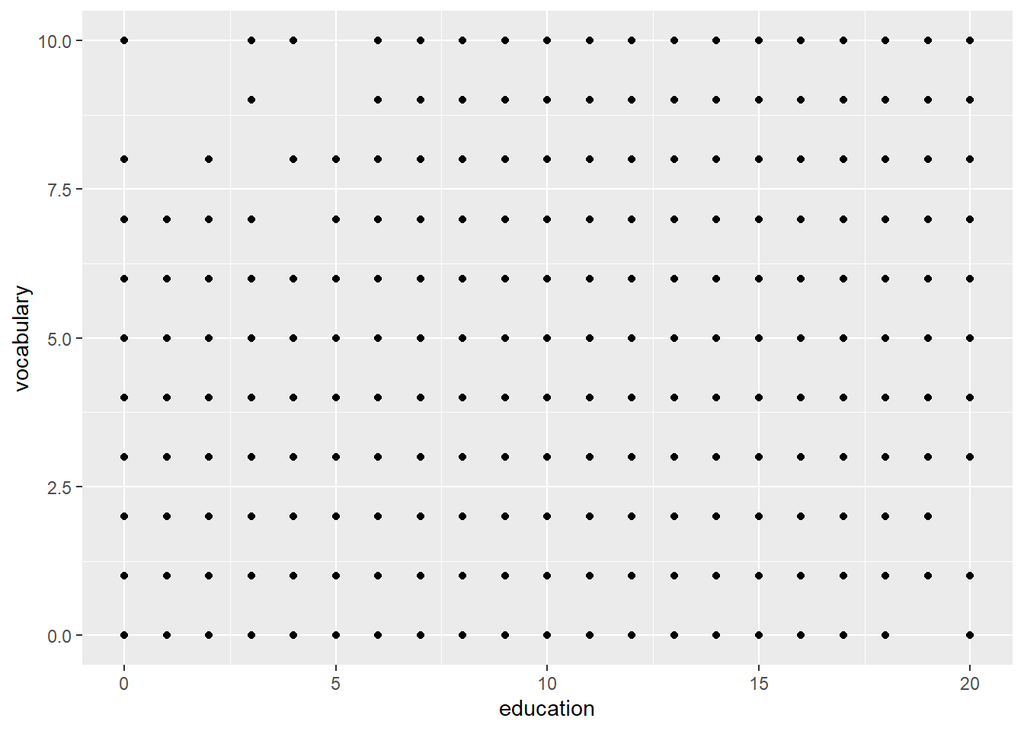

```r
ggplot(Vocab, aes(education, vocabulary)) +
  geom_point()
```

Replace the point layer with a jitter layer and change the transparency.

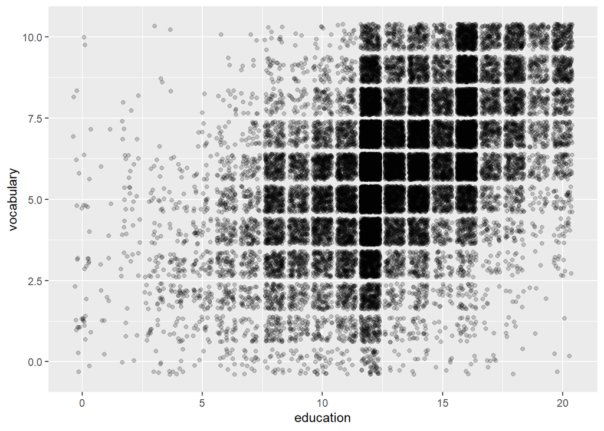

```r
ggplot(Vocab, aes(education, vocabulary)) +
  geom_jitter(alpha = 0.2)
```

### 3.3 Histograms

A histogram is a special type of bar plot that shows the binned distribution of a continuous variable.

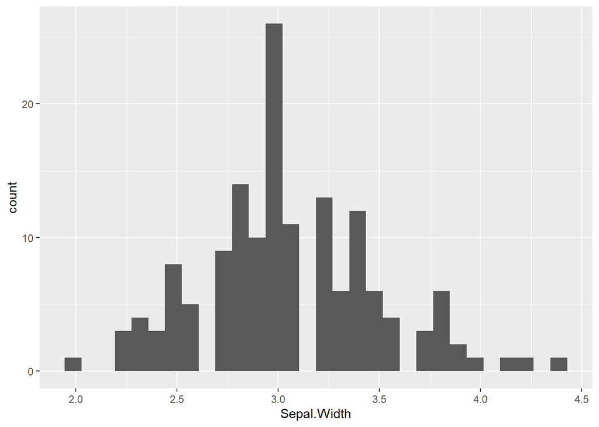

```r
ggplot(iris, aes(Sepal.Width)) + # only needs X aesthetic.
  geom_histogram()
```

The `geom_histogram` is associated with a specific statistic (stat bin). The bin argument takes the default value of 30. Default bin width can be calculated:

```r
diff(range(iris$Sepal.Width))/30
```

```
## [1] 0.08
```

Changing the `binwidth` argument to 0.1 give us more intuitive impression of the data.

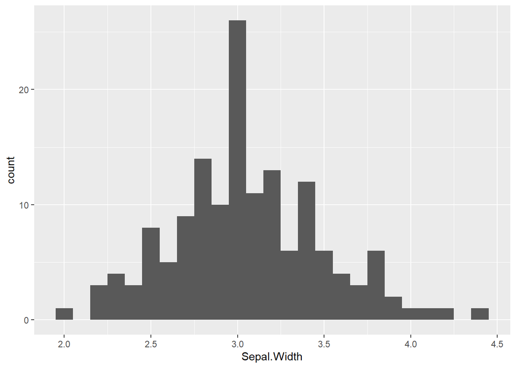

```r
ggplot(iris, aes(Sepal.Width)) +
  geom_histogram(binwidth = 0.1)
```

Note that there is now no space between the bars. That emphasizes that this is a representation of an underlying continuous distribution. That is also why the labels on the X axis should not fall directly on the bars but between the bars. They represent intervals, not actual values. Setting the `center` argument does the trick.

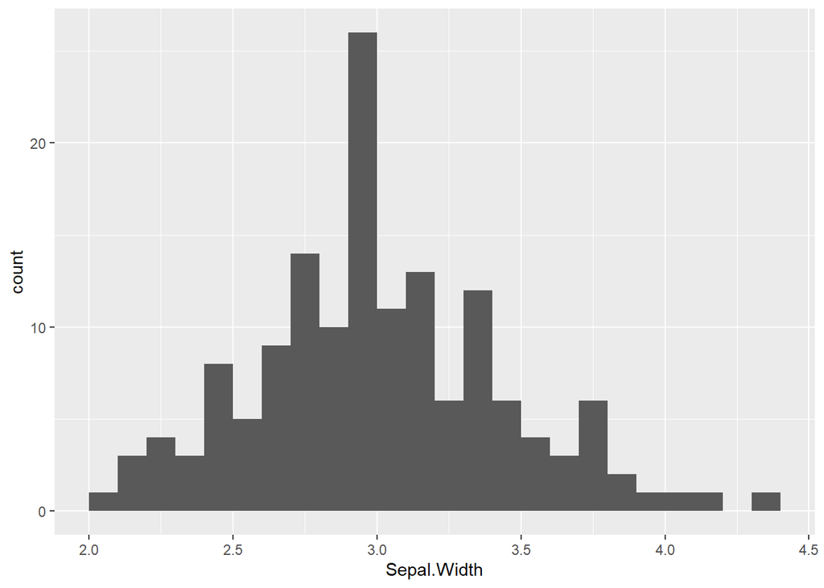

```r
ggplot(iris, aes(Sepal.Width)) +
  geom_histogram(binwidth = 0.1,
                 center = 0.05)
```

Fill the bars according to each species; this makes it clear that we have three histograms in the same plotting space.

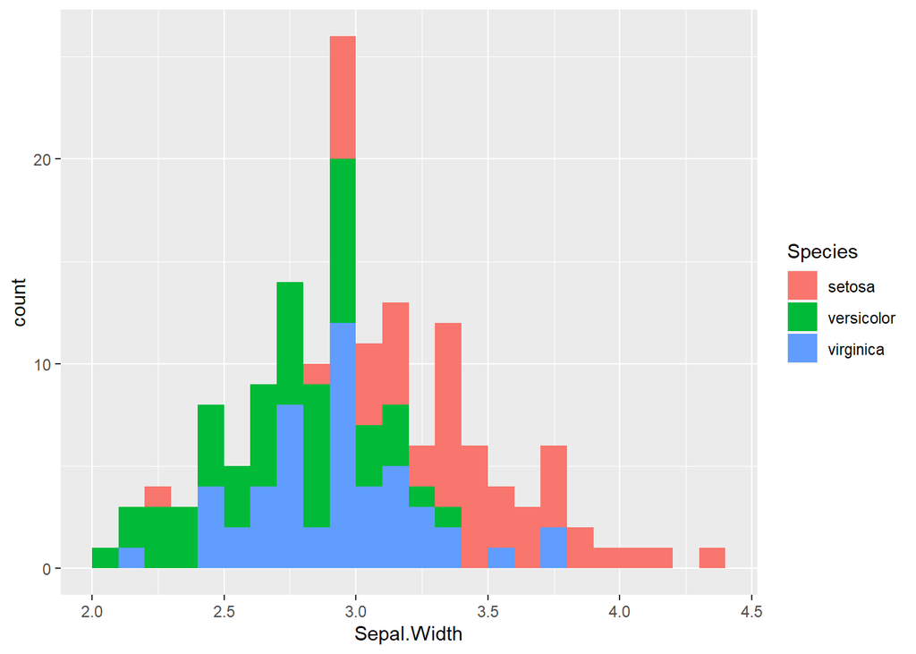

```r
ggplot(iris, aes(Sepal.Width,
                 fill = Species)) +
  geom_histogram(binwidth = 0.1,
                 center = 0.05)
```

There is a perceptual problem here, because it is not immediately clear if the bars are overlapping or if they are stacked on top of each other. Alternate the default position from `stack` to `dodge`:

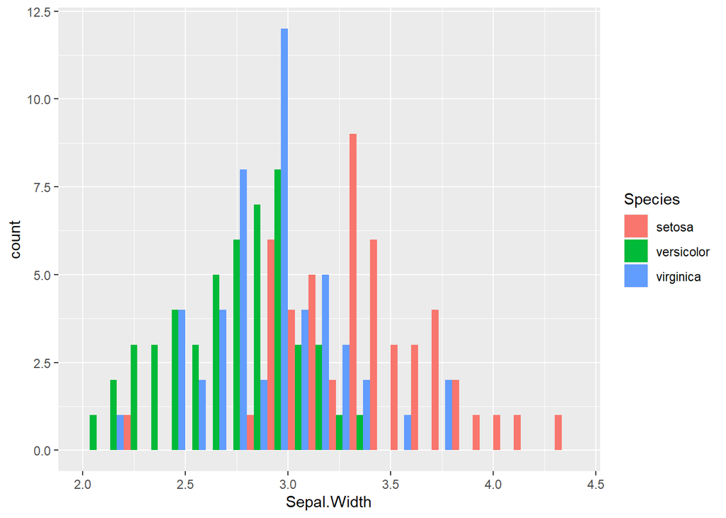

```r
ggplot(iris, aes(Sepal.Width,
                 fill = Species)) +
  geom_histogram(binwidth = 0.1,
                 center = 0.05,
                 position = "dodge")
```

`dodge` is a data viz term which simply means to off-set each data point in a given category. That works but the number of categories make it difficult to see what is happening.

The `fill` position normalizes each bin to represent the proportion of all observations in each bin.

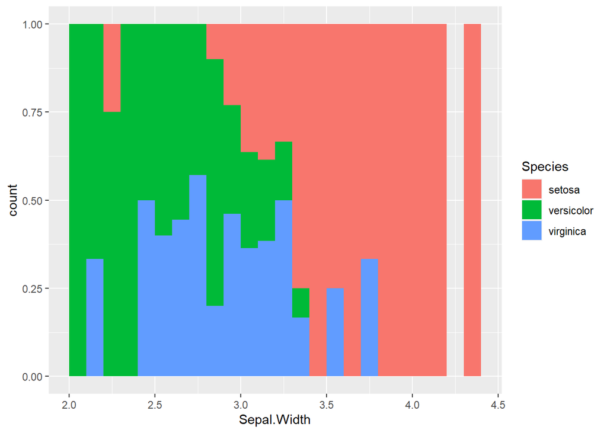

```r
ggplot(iris, aes(Sepal.Width,
                 fill = Species)) +
  geom_histogram(binwidth = 0.1,
                 center = 0.05,
                 position = "fill")
```

The Y axis does not change, but it should say “proportion”, not “count”.

Histograms cut up a continuous variable into discrete bins and, by default, maps the internally calculated count variable onto the `y` aesthetic. An internal variable `..density..` can be accessed by using the `..` notation. This shows the relative frequency, which is the height times the width of each bin.

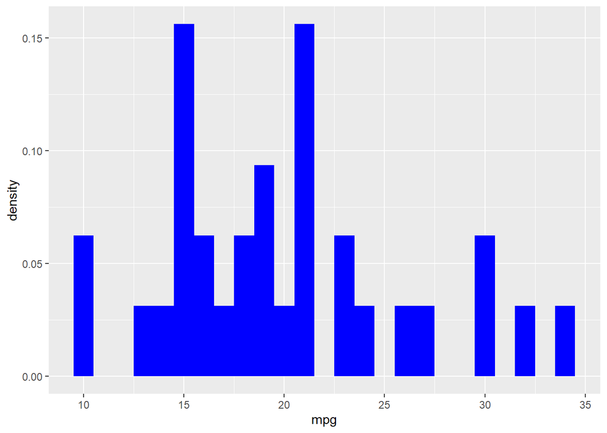

```r
ggplot(mtcars, aes(mpg, ..density..)) +
  geom_histogram(binwidth = 1,
                 fill = "blue")
```

`geom_histogram()` is a special case of `geom_bar()` with a `position` argument that can take on different values:

- `stack` (default): bars for different groups are stacked on top of each other.

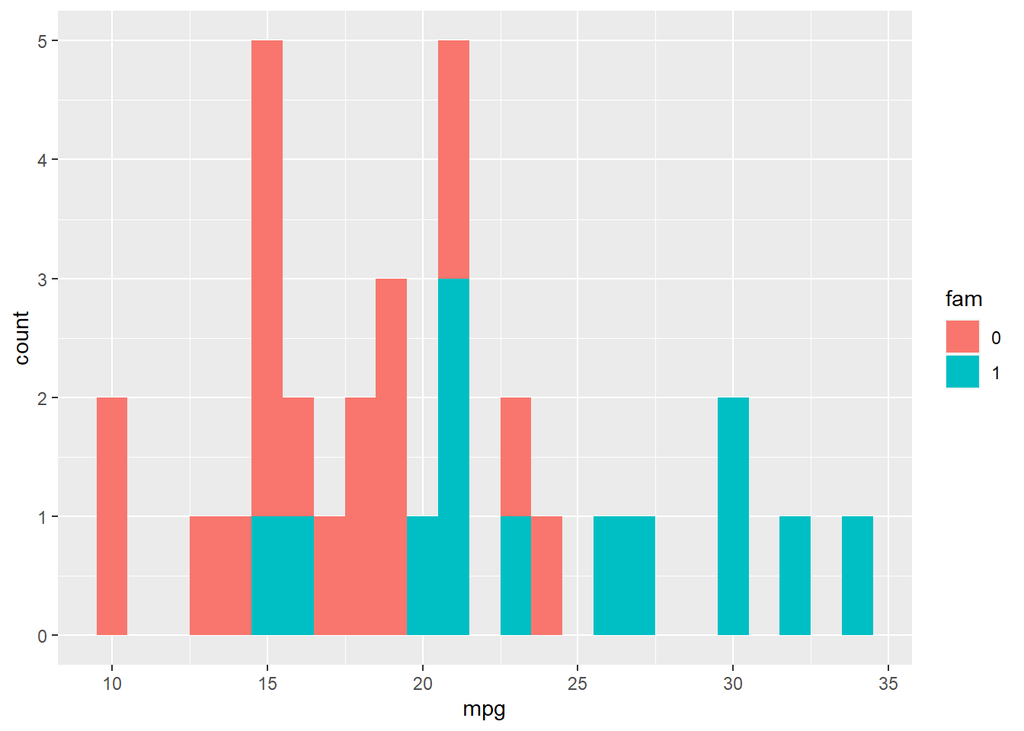

```r
ggplot(mtcars, aes(mpg,
                   fill = fam)) +
  geom_histogram(binwidth = 1)
```

- `dodge`: bars for different groups are placed side by side.

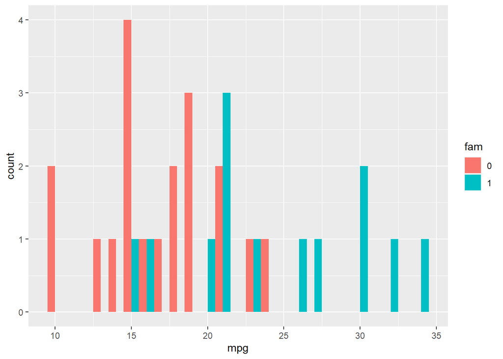

```r
ggplot(mtcars, aes(mpg,
                   fill = fam)) +
  geom_histogram(binwidth = 1,
                 position = "dodge")
```

- `fill`: bars for different groups are shown as proportions.

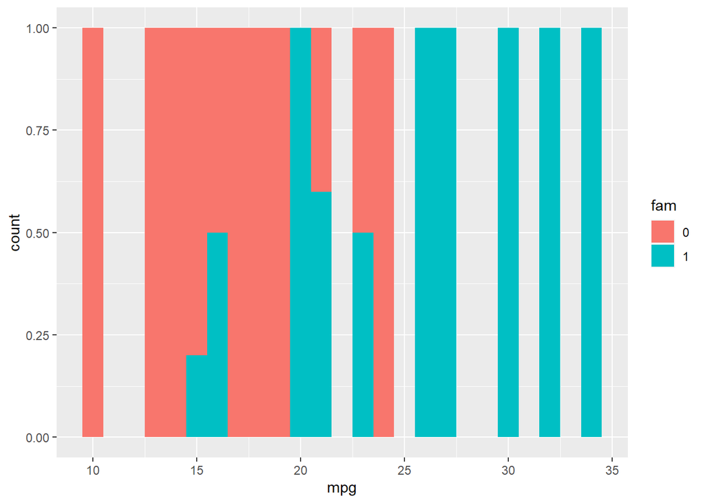

```r
ggplot(mtcars, aes(mpg,
                   fill = fam)) +
  geom_histogram(binwidth = 1,
                 position = "fill")
```

- `identity`: plot the values as they appear in the dataset.

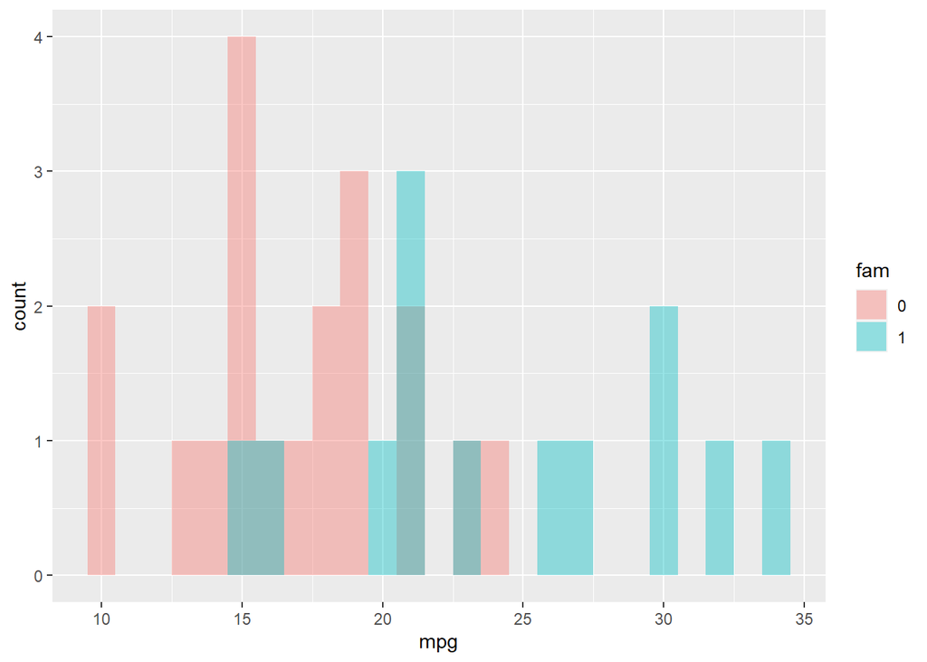

```r
ggplot(mtcars, aes(mpg,
                   fill = fam)) +
  geom_histogram(binwidth = 1,
                 position = "identity",
                 alpha = 0.4)
```

### 3.4 Bar plots

Common plot types for bar plots:

- `geom_histogram()`
- `geom_bar()`
- `geom_col()`
- `geom_errorbar()`

Histograms are a specialized version of bar plots, where a continuous X-axis is binned. Classic bar plots refer to a categorical X-axis, which uses either `geom_bar()` or `geom_col()`.

- `geom_bar()`: counts the number of cases in each category of the variable mapped to the X-axis.
- `geom_col()`: plots the actual values.

Bar plots are mostly use for depicting either absolute counts or distributions.

We will use the `msleep` dataset from the **ggplot2** package, which contains information on the REM sleep time and eating habits of a variety of mammals.

```r
data("msleep")
str(msleep)
```

```
## tibble [83 x 11] (S3: tbl_df/tbl/data.frame)
##  $ name        : chr [1:83] "Cheetah" "Owl monkey" "Mountain beaver" "Greater short-tailed shrew" ...
##  $ genus       : chr [1:83] "Acinonyx" "Aotus" "Aplodontia" "Blarina" ...
##  $ vore        : chr [1:83] "carni" "omni" "herbi" "omni" ...
##  $ order       : chr [1:83] "Carnivora" "Primates" "Rodentia" "Soricomorpha" ...
##  $ conservation: chr [1:83] "lc" NA "nt" "lc" ...
##  $ sleep_total : num [1:83] 12.1 17 14.4 14.9 4 14.4 8.7 7 10.1 3 ...
##  $ sleep_rem   : num [1:83] NA 1.8 2.4 2.3 0.7 2.2 1.4 NA 2.9 NA ...
##  $ sleep_cycle : num [1:83] NA NA NA 0.133 0.667 ...
##  $ awake       : num [1:83] 11.9 7 9.6 9.1 20 9.6 15.3 17 13.9 21 ...
##  $ brainwt     : num [1:83] NA 0.0155 NA 0.00029 0.423 NA NA NA 0.07 0.0982 ...
##  $ bodywt      : num [1:83] 50 0.48 1.35 0.019 600 ...
```

In this bar plot we split the dataset according to eating behavior and simply ask how many observations there are in each category.

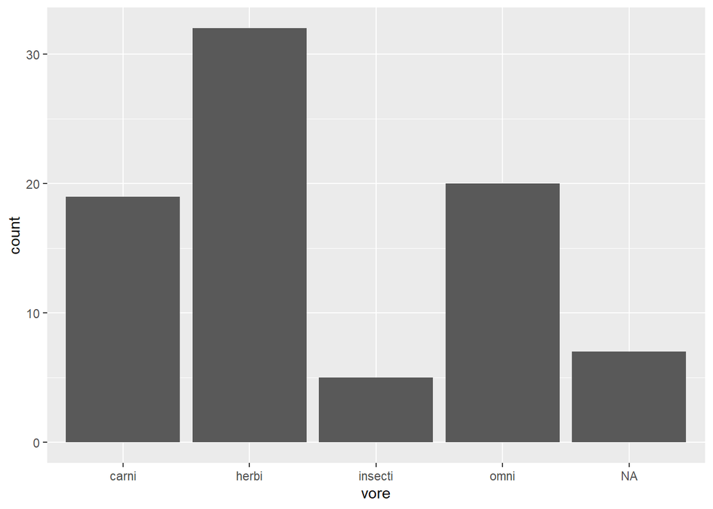

```r
ggplot(msleep, aes(vore)) +
  geom_bar()
```

```r
iris_summ_long <- iris %>%
  select(Species, Sepal.Width) %>%
  gather(key, value, -Species) %>%
  group_by(Species) %>%
  summarise(avg = mean(value),
            stdev = sd(value))
```

Ggplot2 can also plot these statistics on the fly.

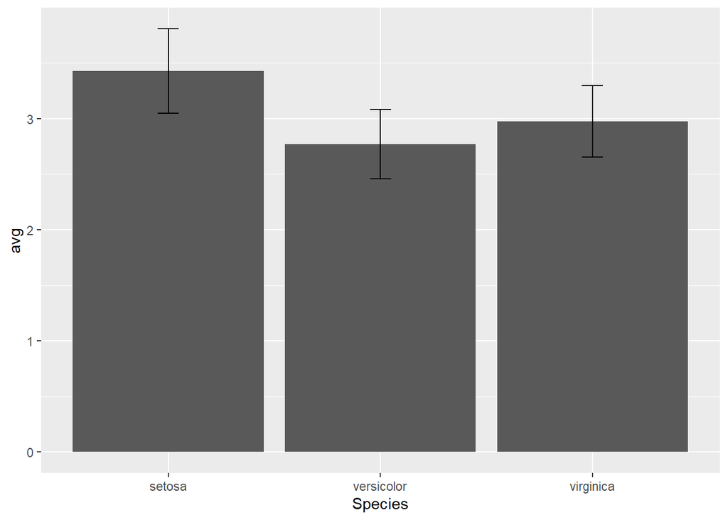

```r
ggplot(iris_summ_long, aes(Species, avg)) +
  geom_col() +
  geom_errorbar(aes(ymin = avg - stdev,
                    ymax = avg + stdev),
                width = 0.1)
```

In this case, we need to use `geom_col()` to map the average column in the dataset onto the `y` aesthetics. The `geom_errorbar` adds error bars with some specific aesthetics, namely `ymin` and `ymax`.

This type of plot is called *dynamite plot*, which is typical plot in scientific publications. But it is actually strongly discouraged for many reasons.